# Diatom-based ecological multivariate analyses

Vélez-Agudelo Camilo

8/3/2022

# **Colorado River**

## Loading Biological Data

This dataset contains diatom data of 15 modern surface sediments samples collected in the middle and lower basin of the Colora River, Patagonia.

```r
speciesRC <- readRDS("speciesRC.rds") ##Importing Diatom Data##
```

## Diatom diagram of common species

Remove diatom taxa where relative abundance is less than 4%

```r
## This code estimates the relative abundance of each diatom specie##
speciesRC.rel <- (decostand(
    speciesRC,
    "total",
    MARGIN = 1)
    ) * 100

speciesRC.rel2 <- colSums(speciesRC.rel) ##Calculate column sums

##Subset data keeping only diatom species with relative abundance greater than 4%##
speciesRC.red <- speciesRC.rel[, which(speciesRC.rel2 > 4)]
```

Cluster analyses of untransformed diatom data.

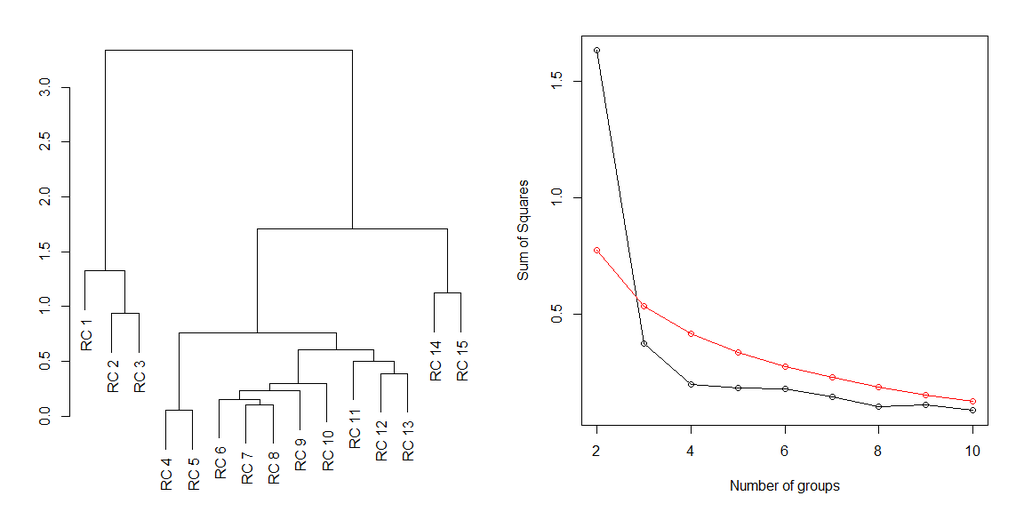

```r
dis.brayRC <- vegdist(
    x = speciesRC.rel,
    method = "bray"
    )

clustRC <- chclust(
    dis.brayRC,
    method = "coniss"
    )

par(mfrow=c(1,2))
plot(clustRC,labels = NULL)
bstick(clustRC, plot = TRUE)
```

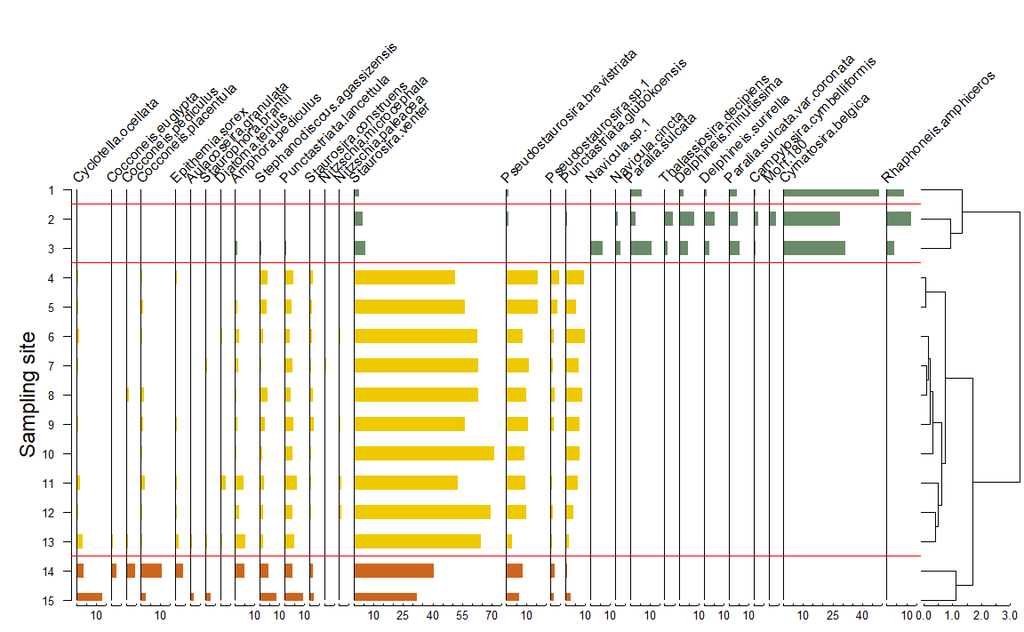

```r
colorRC <- c(
    rep("darkseagreen4", 3),
    rep("gold2", 10),
    rep("chocolate3", 2)
    )

y.scaleRC <- 1:15

p1 <- strat.plot(
    speciesRC.red,
    xLeft = 0.07,
    xRight = 1,
    yBottom = 0.05,
    yTop = 0.7,
    y.rev = T,
    yvar = y.scaleRC,
    y.tks = y.scaleRC,
    scale.percent = T,
    plot.line = F,
    plot.bar = T,
    lwd.bar = 16,
    ylabel = "Sampling site",
    srt.xlabel = 45,
    xSpace = 0.005,
    wa.order = "bottomleft",
    x.pc.inc = 5,
    x.pc.lab = T,
    cex.ylabel = 1.5,
    cex.xlabel = 1,
    cex.yaxis = 0.8,
    col.bar = colorRC,
    col.line = colorRC,
    clust = clustRC,
    tck = 5,
    tcl = 0.1,
    sep.bar = T,
    add.smooth = F,
    smooth.span = 0.1
    )

addClustZone(p1, clustRC, 4, col = "red")
```

# **Negro River**

## Loading Biological Data

This dataset contains diatom data of 18 modern surface sediments samples collected in the middle and lower basin of the Negro River, Patagonia.

```r
speciesRN <- readRDS("speciesRN.rds") ##Importing Diatom Data##
```

## Diatom diagram of common species

Remove diatom taxa where relative abundance is less than 4%

```r
## This code estimates the relative abundance of each diatom specie##
speciesRN.rel <- (decostand(
    speciesRN,
    "total",
    MARGIN = 1)
    ) * 100

speciesRN.rel2 <- colSums(speciesRN.rel) ##Calculate column sums

##Subset data keeping only diatom species with relative abundance greater than 4%##
speciesRN.red <- speciesRN.rel[, which(speciesRN.rel2 > 4)]
```

Cluster analyses of untransformed diatom data.

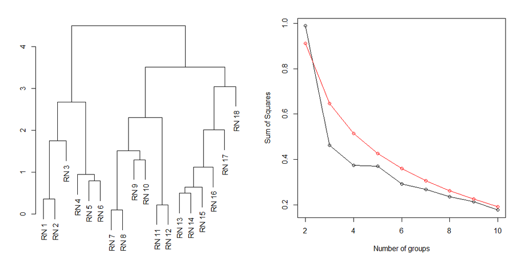

```r
dis.brayRN <- vegdist(
    x = speciesRN.rel,
    method = "bray"
    )

clustRN <- chclust(
    dis.brayRN,
    method = "coniss"
    )

par(mfrow = c(1, 2))
plot(clustRN,labels = NULL)
bstick(clustRN, plot = TRUE)
```

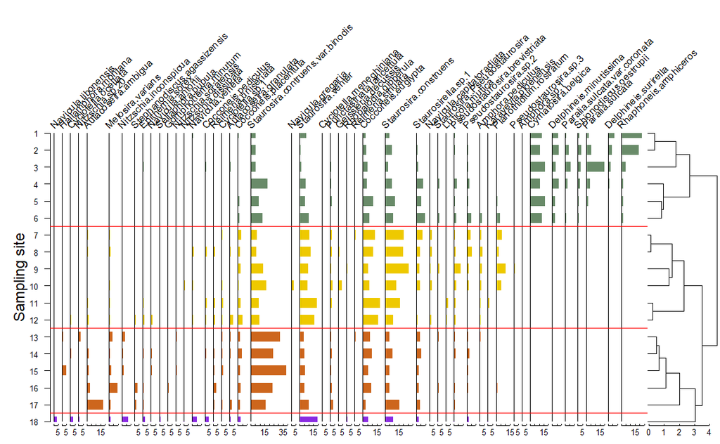

```r
colorRN <- c(
    rep("darkseagreen4", 6),
    rep("gold2", 6),
    rep("chocolate3", 5),
    rep("blueviolet", 1)
    )

y.scaleRN <- 1:18

p2 <- strat.plot(
    speciesRN.red,
    xLeft = 0.07,
    xRight = 1,
    yBottom = 0.05,
    yTop = 0.7,
    y.rev = T,
    yvar = y.scaleRN,
    y.tks = y.scaleRN,
    scale.percent = T,
    plot.line = F,
    plot.bar = T,
    lwd.bar = 16,
    ylabel = "Sampling site",
    srt.xlabel = 45,
    xSpace = 0.005,
    wa.order = "bottomleft",
    x.pc.inc = 5,
    x.pc.lab = T,
    cex.ylabel = 1.5,
    cex.xlabel = 1,
    cex.yaxis = 0.8,
    col.bar = colorRN,
    col.line = colorRN,
    clust = clustRN,
    tck = 5,
    tcl = 0.1,
    sep.bar = T,
    add.smooth = F,
    smooth.span = 0.1
    )

addClustZone(p2, clustRN, 4, col = "red")
```

## Non-metric Multidimensional Scaling (NMDS)

Analyses based on the diatom composition from Negro River. Contour lines show a smoothed surface of the abundance relative of Staurosira binodis (a), Staurosira construens (b), Cocconeis placentula (c) and Cocconeis euglypta (d). Filled black circles represent the estimate abundance relative in each sampling site.

```r
speciesRN.hel <- decostand(speciesRN, "hellinger") ##Transformation of the species data##

speciesRN.nmds <- metaMDS(speciesRN.hel, distance = "bray")
```

```r
par(mfrow=c(2,2))
ordisurf(
  speciesRN.nmds,
  speciesRN.red[, "Staurosira.contruens.var.binodis"],
  main = "Staurosira binodis Relative Abundance",
  bubble = TRUE,
  pch = 16,
  col = "darkseagreen4",
  cex = 3,
  xlim = c(-0.8, 0.8),
  nlevels = 20,
  display = "sites",
  bg = "black"
  )
```

```r
text(speciesRN.nmds,
     display = "sites",
     cex=0.8
     )
```

```r
ordisurf(
  speciesRN.nmds,
  speciesRN.red[, "Staurosira.construens"],
  main = "Staurosira construens Relative Abundance",
  bubble = TRUE,
  pch = 16,
  col = "darkseagreen4",
  cex = 3,
  nlevels = 20,
  display = "sites",
  bg = "black"
  )
```

```r
text(speciesRN.nmds,
     display = "sites",
     cex=0.8
     )
```

```r
ordisurf(
  speciesRN.nmds,
  speciesRN.red[, "Cocconeis.placentula"],
  main = "Cocconeis placentula Relative Abundance",
  bubble = TRUE,
  pch = 16,
  col = "darkseagreen4",
  cex = 3,
  nlevels = 20,
  display = "sites",
  bg = "black"
  )
```

```r
text(speciesRN.nmds,
     display = "sites",
     cex=0.8
     )
```

```r
ordisurf(
  speciesRN.nmds,
  speciesRN.red[, "Cocconeis.euglypta"],
  main = "Cocconeis euglypta Relative Abundance",
  bubble = TRUE,
  pch = 16,
  col = "darkseagreen4",
  cex = 3,
  nlevels = 20,
  display = "sites",
  bg = "black"
  )
```

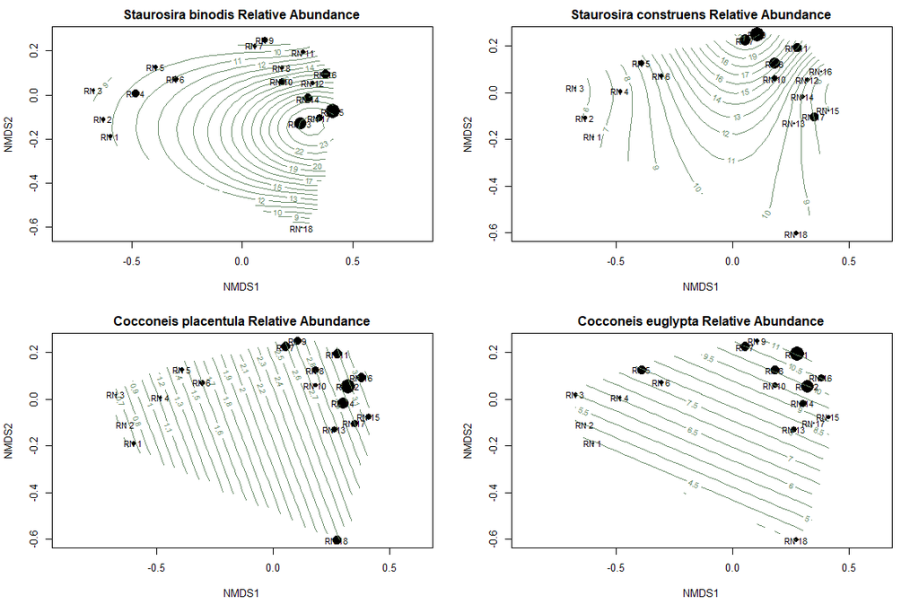

```r
text(speciesRN.nmds,
     display = "sites",
     cex=0.8
     )
```

# **Chubut River**

## Loading Biological Data

```r
speciesCH <- readRDS("speciesCH.rds") ##Importing Diatom Data##
```

## Diatom diagram of common species

Remove diatom taxa where relative abundance is less than 4%

```r
## This code estimates the relative abundance of each diatom specie##
speciesCH.rel <- (decostand(
    speciesCH,
    "total",
    MARGIN = 1)
    ) * 100

speciesCH.rel2 <- colSums(speciesCH.rel) ##Calculate column sums

##Subset data keeping only diatom species with relative abundance greater than 4%##
speciesCH.red <- speciesCH.rel[, which(speciesCH.rel2 > 4)]
```

Cluster analyses of untransformed diatom data.

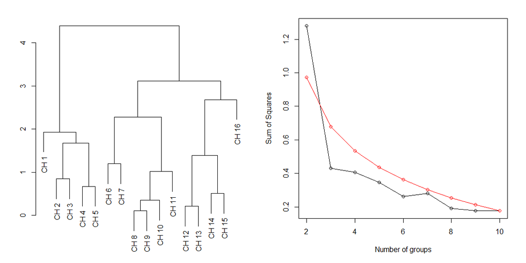

```r
dis.brayCH <- vegdist(
    x = speciesCH.rel,
    method = "bray"
    )

clustCH <- chclust(
    dis.brayCH,
    method = "coniss"
    )

par(mfrow = c(1, 2))
plot(clustCH,labels = NULL)
bstick(clustCH, plot = TRUE)
```

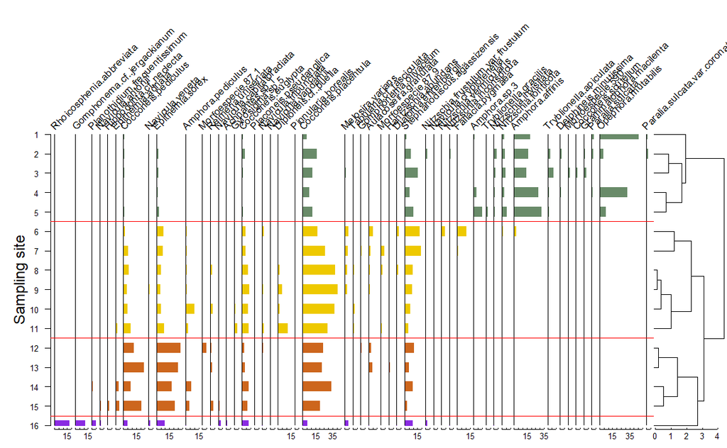

```r
colorCH <- c(
    rep("darkseagreen4", 5),
    rep("gold2", 6),
    rep("chocolate3", 4),
    rep("blueviolet", 1)
    )

y.scaleCH <- 1:16

p3 <- strat.plot(
    speciesCH.red,
    xLeft = 0.07,
    xRight = 1,
    yBottom = 0.05,
    yTop = 0.7,
    y.rev = T,
    yvar = y.scaleCH,
    y.tks = y.scaleCH,
    scale.percent = T,
    plot.line = F,
    plot.bar = T,
    lwd.bar = 16,
    ylabel = "Sampling site",
    srt.xlabel = 45,
    xSpace = 0.005,
    wa.order = "bottomleft",
    x.pc.inc = 5,
    x.pc.lab = T,
    cex.ylabel = 1.5,
    cex.xlabel = 1,
    cex.yaxis = 0.8,
    col.bar = colorCH,
    col.line = colorCH,
    clust = clustCH,
    tck = 5,
    tcl = 0.1,
    sep.bar = T,
    add.smooth = F,
    smooth.span = 0.1
    )

addClustZone(p3, clustCH, 4, col = "red")
```

## Non-metric Multidimensional Scaling (NMDS)

```r
speciesCH.hel <- decostand(speciesCH, "hellinger") ##Transformation of the species data##

speciesCH.nmds <- metaMDS(speciesCH.hel, distance = "bray")
```

```r
par(mfrow = c(2, 2))
ordisurf(
  speciesCH.nmds,
  speciesCH.red[, "Amphora.affinis"],
  main = "Amphora affinis Relative Abundance",
  bubble = TRUE,
  pch = 16,
  col = "darkseagreen4",
  cex = 3,
  nlevels = 20,
  display = "sites",
  bg = "black"
  )
```

```r
text(speciesCH.nmds,
     display = "sites",
     cex=0.8
     )
```

```r
ordisurf(
  speciesCH.nmds,
  speciesCH.red[, "Cocconeis.placentula"],
  main = "Cocconeis placentula Relative Abundance",
  bubble = TRUE,
  pch = 16,
  col = "darkseagreen4",
  cex = 3,
  nlevels = 20,
  display = "sites",
  bg = "black"
  )
```

```r
text(speciesCH.nmds,
     display = "sites",
     cex=0.8
     )
```

```r
ordisurf(
  speciesCH.nmds,
  speciesCH.red[, "Stephanodiscus.agassizensis"],
  main = "Stephanodiscus agassizensis Relative Abundance",
  bubble = TRUE,
  pch = 16,
  col = "darkseagreen4",
  cex = 3,
  nlevels = 20,
  display = "sites",
  bg = "black"
  )
```

```r
text(speciesCH.nmds,
     display = "sites",
     cex=0.8
     )
```

```r
ordisurf(
  speciesCH.nmds,
  speciesCH.red[, "Cocconeis.euglypta"],
  main = "Cocconeis euglypta Relative Abundance",
  bubble = TRUE,
  pch = 16,
  col = "darkseagreen4",
  cex = 3,
  nlevels = 20,
  display = "sites",
  bg = "black"
  )
```

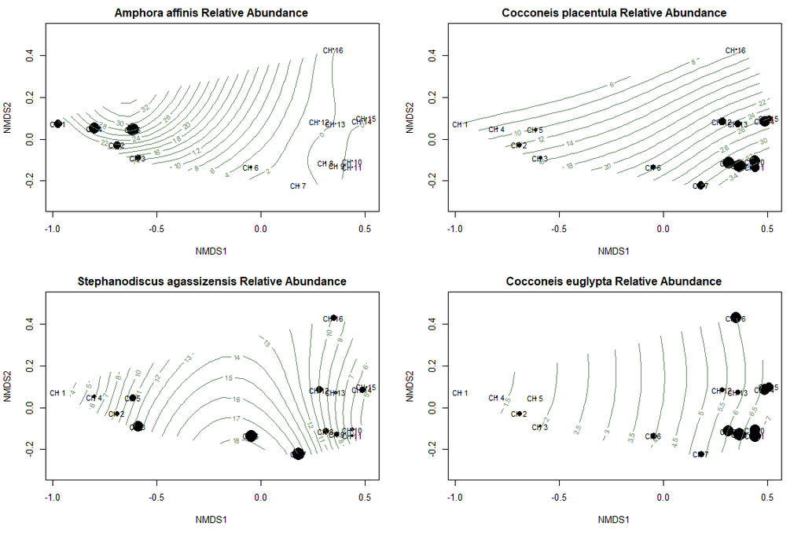

```r
text(speciesCH.nmds,
     display = "sites",
     cex=0.8
     )
```

# **Diversity Indices**

## Diversity Colorado River

```r
S.RC <- specnumber(speciesRC.rel) ##Species richness##
H.RC <- diversity(speciesRC.rel, index="shannon") ##Shannon index##
D.RC <- diversity(speciesRC.rel, index="simpson") ##Simpson index##
INV.RC <- diversity(speciesRC.rel,index="invsimpson") ##Simpson inverse##
N.RC <- 1/(1-D.RC) ##Effective Number of Simpson##
J.RC <- H.RC/log(S.RC) ##Pielou Evenness

divRC <- data.frame(S.RC, H.RC, D.RC, INV.RC, N.RC, J.RC)
```

```r
kable(divRC, digits = 2, caption = "Diversity indices in the Colorado River", col.names = c("Sp. Richness", "Shannon", "Simpson", "Simpson Inv.", "Effecive Simp", "Pielou")) %>%
  kable_styling(bootstrap_options = c("striped", "hover"), full_width = F, position = "center")
```

Diversity indices in the Colorado River

|  | Sp. Richness | Shannon | Simpson | Simpson Inv. | Effecive Simp | Pielou |
| --- | --- | --- | --- | --- | --- | --- |
| RC 1 | 65 | 2.41 | 0.75 | 3.95 | 3.95 | 0.58 |
| RC 2 | 63 | 2.90 | 0.88 | 8.40 | 8.40 | 0.70 |
| RC 3 | 70 | 2.88 | 0.87 | 7.72 | 7.72 | 0.68 |
| RC 4 | 30 | 1.77 | 0.69 | 3.24 | 3.24 | 0.52 |
| RC 5 | 31 | 1.71 | 0.65 | 2.83 | 2.83 | 0.50 |
| RC 6 | 30 | 1.59 | 0.58 | 2.41 | 2.41 | 0.47 |
| RC 7 | 31 | 1.58 | 0.58 | 2.39 | 2.39 | 0.46 |
| RC 8 | 22 | 1.47 | 0.58 | 2.38 | 2.38 | 0.48 |
| RC 9 | 40 | 1.88 | 0.66 | 2.93 | 2.93 | 0.51 |
| RC 10 | 22 | 1.19 | 0.47 | 1.90 | 1.90 | 0.39 |
| RC 11 | 41 | 2.02 | 0.70 | 3.33 | 3.33 | 0.54 |
| RC 12 | 20 | 1.29 | 0.50 | 1.99 | 1.99 | 0.43 |
| RC 13 | 38 | 1.72 | 0.57 | 2.34 | 2.34 | 0.47 |
| RC 14 | 33 | 2.30 | 0.80 | 5.07 | 5.07 | 0.66 |
| RC 15 | 46 | 2.60 | 0.86 | 6.90 | 6.90 | 0.68 |

## Diversity Negro River

```r
S.RN <- specnumber(speciesRN.rel) ##Species richness##
H.RN <- diversity(speciesRN.rel, index="shannon") ##Shannon index##
D.RN <- diversity(speciesRN.rel, index="simpson") ##Simpson index##
INV.RN <- diversity(speciesRN.rel,index="invsimpson") ##Simpson inverse##
N.RN <- 1/(1-D.RN) ##Effective Number of Simpson##
J.RN <- H.RN/log(S.RN) ##Pielou Evenness

divRN <- data.frame(S.RN, H.RN, D.RN, INV.RN, N.RN, J.RN)
```

```r
kable(divRN, digits = 2, caption = "Diversity indices in the Negro River", col.names = c("Sp. Richness", "Shannon", "Simpson", "Simpson Inv.", "Effecive Simp", "Pielou")) %>%
  kable_styling(bootstrap_options = c("striped", "hover"), full_width = F, position = "center")
```

Diversity indices in the Negro River

|  | Sp. Richness | Shannon | Simpson | Simpson Inv. | Effecive Simp | Pielou |
| --- | --- | --- | --- | --- | --- | --- |
| RN 1 | 69 | 3.05 | 0.91 | 10.78 | 10.78 | 0.72 |
| RN 2 | 77 | 3.24 | 0.93 | 13.54 | 13.54 | 0.75 |
| RN 3 | 65 | 3.11 | 0.92 | 11.78 | 11.78 | 0.75 |
| RN 4 | 54 | 3.06 | 0.92 | 13.31 | 13.31 | 0.77 |
| RN 5 | 80 | 3.30 | 0.93 | 14.16 | 14.16 | 0.75 |
| RN 6 | 54 | 3.04 | 0.93 | 13.76 | 13.76 | 0.76 |
| RN 7 | 57 | 2.97 | 0.91 | 11.27 | 11.27 | 0.74 |
| RN 8 | 67 | 3.12 | 0.92 | 12.35 | 12.35 | 0.74 |
| RN 9 | 44 | 2.66 | 0.88 | 8.46 | 8.46 | 0.70 |
| RN 10 | 80 | 3.32 | 0.93 | 14.72 | 14.72 | 0.76 |
| RN 11 | 59 | 2.83 | 0.89 | 9.06 | 9.06 | 0.69 |
| RN 12 | 67 | 3.17 | 0.92 | 12.46 | 12.46 | 0.75 |
| RN 13 | 74 | 3.11 | 0.88 | 8.40 | 8.40 | 0.72 |
| RN 14 | 83 | 3.28 | 0.91 | 11.56 | 11.56 | 0.74 |
| RN 15 | 70 | 2.87 | 0.84 | 6.11 | 6.11 | 0.68 |
| RN 16 | 74 | 3.21 | 0.91 | 11.69 | 11.69 | 0.75 |
| RN 17 | 71 | 2.94 | 0.90 | 10.07 | 10.07 | 0.69 |
| RN 18 | 84 | 3.43 | 0.93 | 15.15 | 15.15 | 0.77 |

## Diversity Chubut River

```r
S.CH <- specnumber(speciesCH.rel) ##Species richness##
H.CH <- diversity(speciesCH.rel, index="shannon") ##Shannon index##
D.CH <- diversity(speciesCH.rel, index="simpson") ##Simpson index##
INV.CH <- diversity(speciesCH.rel,index="invsimpson") ##Simpson inverse##
N.CH <- 1/(1-D.CH) ##Effective Number of Simpson##
J.CH <- H.CH/log(S.CH) ##Pielou Evenness

divCH <- data.frame(S.CH, H.CH, D.CH, INV.CH, N.CH, J.CH)
```

```r
kable(divCH, digits = 2, caption = "Diversity indices in the Chubut River", col.names = c("Sp. Richness", "Shannon", "Simpson", "Simpson Inv.", "Effecive Simp", "Pielou")) %>%
  kable_styling(bootstrap_options = c("striped", "hover"), full_width = F, position = "center")
```

Diversity indices in the Chubut River

|  | Sp. Richness | Shannon | Simpson | Simpson Inv. | Effecive Simp | Pielou |
| --- | --- | --- | --- | --- | --- | --- |
| CH 1 | 50 | 2.23 | 0.75 | 4.01 | 4.01 | 0.57 |
| CH 2 | 76 | 3.29 | 0.93 | 13.44 | 13.44 | 0.76 |
| CH 3 | 79 | 3.34 | 0.93 | 13.96 | 13.96 | 0.76 |
| CH 4 | 52 | 2.28 | 0.80 | 5.00 | 5.00 | 0.58 |
| CH 5 | 50 | 2.54 | 0.85 | 6.78 | 6.78 | 0.65 |
| CH 6 | 69 | 3.01 | 0.91 | 11.08 | 11.08 | 0.71 |
| CH 7 | 73 | 2.93 | 0.88 | 8.21 | 8.21 | 0.68 |
| CH 8 | 62 | 2.69 | 0.83 | 5.86 | 5.86 | 0.65 |
| CH 9 | 65 | 2.63 | 0.81 | 5.24 | 5.24 | 0.63 |
| CH 10 | 60 | 2.69 | 0.84 | 6.07 | 6.07 | 0.66 |
| CH 11 | 60 | 2.79 | 0.87 | 7.98 | 7.98 | 0.68 |
| CH 12 | 35 | 2.23 | 0.83 | 5.86 | 5.86 | 0.63 |
| CH 13 | 40 | 2.22 | 0.82 | 5.67 | 5.67 | 0.60 |
| CH 14 | 40 | 2.27 | 0.82 | 5.71 | 5.71 | 0.61 |
| CH 15 | 39 | 2.41 | 0.86 | 6.97 | 6.97 | 0.66 |
| CH 16 | 46 | 2.91 | 0.92 | 12.10 | 12.10 | 0.76 |

## Comparison of Diversity Indices

```r
names(divRC) <- c("Richness", "Shannon", "Simpson", "Simpson.Inv", "Effective.Simp", "Pielou")

names(divRN) <- c("Richness", "Shannon", "Simpson", "Simpson.Inv", "Effective.Simp", "Pielou")

names(divCH) <- c("Richness", "Shannon", "Simpson", "Simpson.Inv", "Effective.Simp", "Pielou")

Diversity <- Merge(divRC, divRN, divCH)
River <- c(rep("Colorado", 15), rep("Negro", 18), rep("Chubut", 16))
Diversity <- cbind(River, Diversity)

d1 <- ggplot(
  Diversity,
  aes(x = River, y= Richness, fill = River)
  )+
  geom_boxplot(
    outlier.colour = "red",
    outlier.shape = 18,
    outlier.size = 4,
    notch = T
    ) +
  labs(
    title="Species Richness (S)"
    ) +
  scale_fill_brewer(
    palette="Blues"
    )+
  theme_grey()

d2 <- ggplot(
  Diversity,
  aes(x = River, y= Shannon, fill = River)
  )+
  geom_boxplot(
    outlier.colour = "red",
    outlier.shape = 18,
    outlier.size = 4,
    notch = T
    ) +
  labs(
    title="Shannon Diversity (H)"
    ) +
  scale_fill_brewer(
    palette="Blues"
    )+
  theme_grey()

d3 <- ggplot(
  Diversity,
  aes(x = River, y= Simpson, fill = River)
  )+
  geom_boxplot(
    outlier.colour = "red",
    outlier.shape = 18,
    outlier.size = 4,
    notch = T
    ) +
  labs(
    title="Simpson Dominance (D)"
    ) +
  scale_fill_brewer(
    palette="Blues"
    )+
  theme_grey()

d4 <- ggplot(
  Diversity,
  aes(x = River, y= Simpson.Inv, fill = River)
  )+
  geom_boxplot(
    outlier.colour = "red",
    outlier.shape = 18,
    outlier.size = 4,
    notch = T
    ) +
  labs(
    title="Simpson Inverse"
    ) +
  scale_fill_brewer(
    palette="Blues"
    )+
  theme_grey()

d5 <- ggplot(
  Diversity,
  aes(x = River, y= Effective.Simp, fill = River)
  )+
  geom_boxplot(
    outlier.colour = "red",
    outlier.shape = 18,
    outlier.size = 4,
    notch = T
    ) +
  labs(
    title="Effective Simpson"
    ) +
  scale_fill_brewer(
    palette="Blues"
    )+
  theme_grey()

d6 <- ggplot(
  Diversity,
  aes(x = River, y= Pielou, fill = River)
  )+
  geom_boxplot(
    outlier.colour = "red",
    outlier.shape = 18,
    outlier.size = 4,
    notch = T
    ) +
  labs(
    title="Pielou Evenness"
    ) +
  scale_fill_brewer(
    palette="Blues"
    )+
  theme_grey()
```

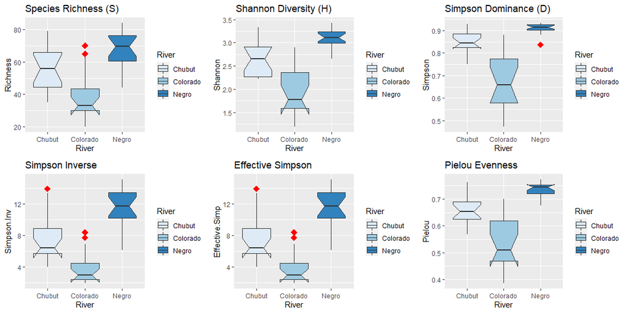

```r
grid.arrange(d1, d2, d3, d4, d5, d6, nrow = 2, ncol =3)
```

# **Redundancy Analysis (RDA)**

Two RDAs were performed, one with the complete dataset (49 sampling sites) and one with the reduced data. The estuarine sites were excluded of the analysis in the last dataset, so as to identify correlations among variables and diatom species only in freshwater sites. In addition, winter and summer values of physical and hidrochemical variables were averaged before performing these ordinations.

## Preparation of Biological and Environmental Data

```r
##Transformation of diatom data##
speciesRC.red.hel <- decostand(speciesRC.red, "hellinger")
speciesRN.red.hel <- decostand(speciesRN.red, "hellinger")
speciesCH.red.hel <- decostand(speciesCH.red, "hellinger")
```

```r
##Code assignment##

colnames(speciesRC.red.hel) <- names[[1]][, 2]
colnames(speciesRN.red.hel) <- names[[2]][, 2]
colnames(speciesCH.red.hel) <- names[[3]][, 2]
```

```r
##Function for combining the diatom datasets of the rivers##

species.complete <- Merge(
  speciesRC.red.hel,
  speciesRN.red.hel,
  speciesCH.red.hel
  )
```

```r
##Loading Environmental Data##
varam <- readRDS("varam.rds")

##Physical and hydrochemical data - LogTranformation (except pH)##
chem <- log1p(varam[, 2:14])
chem <- cbind(varam$pH, chem)
names(chem)[1] <- "pH"

##Sedimentological data - Standardized#
sed <- decostand(varam[, 15:17], MARGIN =2, "standardize")
```

## Partial RDA (Hydrochemical vs Sedimentological Variables)

Variance partitioning with physical and chemical variables as constraining variables and sedimentological variables (grain size and TOC) as covariables was implemented to determine the amount of variation explained by each group.

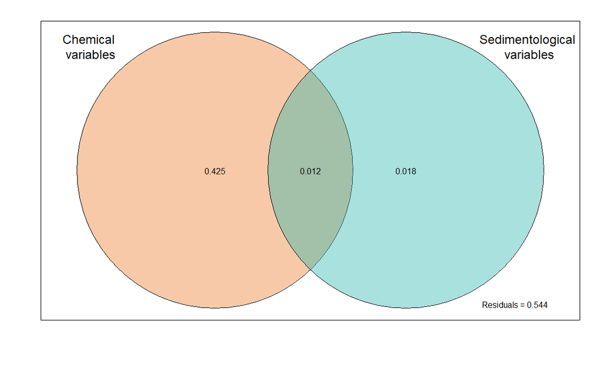

```r
RDA.part <- varpart(
  species.complete,
  chem,
  sed,
  chisquare = T
  )

plot(
  RDA.part,
  digits = 2,
  bg = c("chocolate2", "lightseagreen"),
  alpha = 100,
  id.size = 1.5,
  Xnames = c("Chemical \nvariables", "Sedimentological \nvariables"))
```

## Selection of Explanatory Variables - Complete Data

```r
##RDA with chemical variables including estuarine and inland sites##
species.complete.rda <- rda(species.complete ~ ., data = chem)

select.exp <- rda(species.complete ~ 1, data = chem)
step.forward <-
  ordistep(select.exp,
           scope = formula(species.complete.rda),
           direction = "forward",
           permutations = how(nperm = 999)
  )
```

```
Start: species.complete ~ 1

       Df     AIC       F Pr(>F)
+ SO4   1 -33.559 11.0712  0.001 ***
+ pH    1 -33.061 10.4840  0.001 ***
+ Ca    1 -31.557  8.7470  0.001 ***
+ Hard  1 -31.424  8.5962  0.001 ***
+ Na    1 -30.620  7.6910  0.001 ***
+ Cl    1 -30.426  7.4753  0.001 ***
+ Cond  1 -30.301  7.3358  0.001 ***
+ Sal   1 -30.140  7.1583  0.001 ***
+ Temp  1 -29.941  6.9384  0.001 ***
+ K     1 -29.537  6.4955  0.001 ***
+ CO3H  1 -28.794  5.6904  0.001 ***
+ Mg    1 -28.735  5.6274  0.001 ***
+ SIO2  1 -28.483  5.3570  0.001 ***
+ NO3   1 -24.528  1.2973  0.243
---
Signif. codes:  0 ‘***’ 0.001 ‘**’ 0.01 ‘*’ 0.05 ‘.’ 0.1 ‘ ’ 1

Step: species.complete ~ SO4

       Df     AIC       F Pr(>F)
+ pH    1 -43.794 13.0476  0.001 ***
+ Sal   1 -43.152 12.2784  0.001 ***
+ Cond  1 -43.135 12.2585  0.001 ***
+ Na    1 -42.486 11.4923  0.001 ***
+ Cl    1 -40.406  9.1033  0.001 ***
+ SIO2  1 -39.172  7.7320  0.001 ***
+ K     1 -39.010  7.5554  0.001 ***
+ CO3H  1 -38.868  7.3996  0.001 ***
+ Hard  1 -36.396  4.7733  0.002 **
+ Ca    1 -34.760  3.1054  0.012 *
+ Temp  1 -34.398  2.7438  0.026 *
+ NO3   1 -33.200  1.5670  0.149
+ Mg    1 -32.424  0.8197  0.534
---
Signif. codes:  0 ‘***’ 0.001 ‘**’ 0.01 ‘*’ 0.05 ‘.’ 0.1 ‘ ’ 1

Step: species.complete ~ SO4 + pH
```

[output cut: 68 more lines]

```

Step: species.complete ~ SO4 + pH + Sal + CO3H + SIO2 + Cl

       Df     AIC      F Pr(>F)
+ Hard  1 -58.559 1.6526  0.091 .
+ Temp  1 -58.372 1.4904  0.124
+ NO3   1 -58.319 1.4441  0.145
+ Na    1 -58.297 1.4257  0.145
+ Cond  1 -57.917 1.0975  0.309
+ K     1 -57.810 1.0057  0.412
+ Ca    1 -57.679 0.8933  0.506
+ Mg    1 -57.674 0.8892  0.513
---
Signif. codes:
0 ‘***’ 0.001 ‘**’ 0.01 ‘*’ 0.05 ‘.’ 0.1 ‘ ’ 1
```

```r
RsquareAdj(step.forward)
```

```
$r.squared
[1] 0.6043041

$adj.r.squared
[1] 0.5477762
```

## Triplot RDA - Complete Data

```r
##RDA with hydrochemical variables selected (vs)##
species.rda.vs <- rda(species.complete ~ SO4 + pH + Sal + CO3H + SIO2 + Cl, data = chem)
```

```r
plot(species.rda.vs,
     scaling = 2,
     display = c("sp", "cn", "sites"),
     xlim = c(-0.6, 0.6),
     main = "RDA Analysis \nestuarine and inland sites")
points(
  species.rda.vs,
  "sp",
  pch = 16,
  col = "red"
  )
```

```r
points(
  species.rda.vs,
  "sites",
  pch = 17,
  col = "black"
  )
text(
  species.rda.vs,
  display = "sites",
  cex = 0.5,
  col = "black"
  )
```

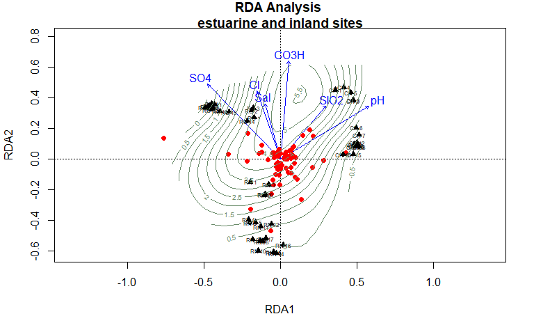

```r
ef <- with(
  varam,
  ordisurf(
    species.rda.vs,
    Sal,
    col = "darkseagreen4",
    display = "lc",
    nlevels = 10,
    add = TRUE)
  )
```

## Partial RDA - Complete Data

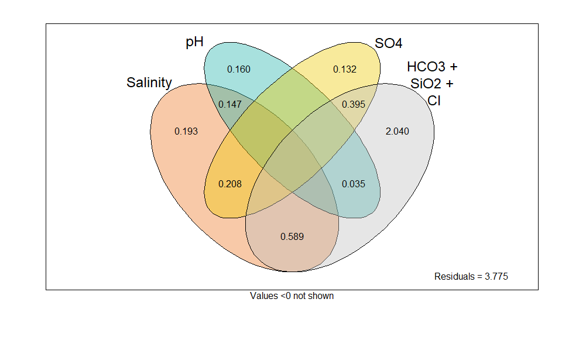

```r
RDA.part1 <- varpart(
  species.complete,
  ~ Sal,
  ~ pH,
  ~ SO4,
  ~ CO3H + SIO2 + Cl,
  data = chem,
  chisquare = T
  )

plot(
  RDA.part1,
  digits = 2,
  bg = c("chocolate2", "lightseagreen", "gold2", "gray"),
  alpha = 100,
  id.size = 1.5,
  Xnames = c("Salinity", "pH", "SO4", "HCO3 + \nSiO2 + \nCl")
  )
```

## Selection of Explanatory Variables - Inland Data

In this case, the estuarine sites (RC1-RC3, RN1-RN3 and CH1-CH5) were removed from the training set because preliminary ordination analyses (with complete data) indicated that salinity, pH and sulphate exerted a strong and similar influence in the diatom response.

```r
##Preparing Data##
species.inland <- species.complete[-c(1:3, 16:18, 34:38),]
species.inland <- species.inland[, colSums(species.inland) > 0]

##Hydrochemical Dat##
chem.inland <- chem[-c(1:3, 16:18, 34:38),]
```

```r
##RDA with chemical variables with only inland sites##
species.inland.rda <- rda(species.inland ~ ., data = chem.inland)

select.exp.inland <- rda(species.inland ~ 1, data = chem.inland)
step.forward.inland <-
  ordistep(select.exp.inland,
           scope = formula(species.inland.rda),
           direction = "forward",
           permutations = how(nperm = 999)
  )
```

```
Start: species.inland ~ 1

       Df     AIC       F Pr(>F)
+ Sal   1 -40.010 19.6832  0.001 ***
+ Cond  1 -39.664 19.1793  0.001 ***
+ SO4   1 -39.531 18.9870  0.001 ***
+ Hard  1 -38.767 17.8919  0.001 ***
+ Ca    1 -38.375 17.3388  0.001 ***
+ Cl    1 -35.353 13.2608  0.001 ***
+ Na    1 -35.071 12.8964  0.001 ***
+ Mg    1 -33.732 11.2046  0.001 ***
+ pH    1 -32.809 10.0717  0.001 ***
+ Temp  1 -31.680  8.7223  0.001 ***
+ CO3H  1 -30.440  7.2864  0.001 ***
+ K     1 -30.299  7.1259  0.001 ***
+ SIO2  1 -27.507  4.0716  0.013 *
+ NO3   1 -25.632  2.1422  0.067 .
---
Signif. codes:  0 ‘***’ 0.001 ‘**’ 0.01 ‘*’ 0.05 ‘.’ 0.1 ‘ ’ 1

Step: species.inland ~ Sal

       Df     AIC       F Pr(>F)
+ pH    1 -51.056 14.3367  0.001 ***
+ CO3H  1 -48.119 10.6669  0.001 ***
+ Temp  1 -45.657  7.8024  0.001 ***
+ SO4   1 -44.352  6.3578  0.003 **
+ SIO2  1 -43.931  5.9021  0.003 **
+ NO3   1 -41.468  3.3353  0.024 *
+ Hard  1 -40.342  2.2160  0.071 .
+ Na    1 -39.447  1.3496  0.227
+ Mg    1 -39.355  1.2617  0.230
+ Cl    1 -39.396  1.3007  0.263
+ Ca    1 -39.244  1.1554  0.267
+ Cond  1 -38.771  0.7087  0.575
+ K     1 -38.566  0.5165  0.727
---
Signif. codes:  0 ‘***’ 0.001 ‘**’ 0.01 ‘*’ 0.05 ‘.’ 0.1 ‘ ’ 1

Step: species.inland ~ Sal + pH
```

[output cut: 34 more lines]

```
Step: species.inland ~ Sal + pH + CO3H + SO4

       Df     AIC      F Pr(>F)
+ Na    1 -58.385 1.8044  0.058 .
+ Cl    1 -58.207 1.6465  0.083 .
+ Hard  1 -58.109 1.5598  0.091 .
+ SIO2  1 -58.019 1.4805  0.139
+ Temp  1 -57.837 1.3208  0.167
+ Cond  1 -57.974 1.4405  0.193
+ K     1 -57.660 1.1654  0.292
+ Mg    1 -57.524 1.0470  0.369
+ NO3   1 -57.405 0.9442  0.459
+ Ca    1 -57.353 0.8991  0.524
---
Signif. codes:  0 ‘***’ 0.001 ‘**’ 0.01 ‘*’ 0.05 ‘.’ 0.1 ‘ ’ 1
```

```r
RsquareAdj(step.forward.inland)
```

```
$r.squared
[1] 0.6588358

$adj.r.squared
[1] 0.6174826
```

Forward selection with unrestricted permutation test showed that pH (p = 0.001), SO4 (p = 0.001), salinity (p = 0.001) and HCO3 (p = 0.001) exert a significant and independent influence on the species distribution.

## Triplot RDA - Inland Data

```r
##RDA with hydrochemical variables selected (vs)##
species.inland.vs <- rda(species.inland ~ pH + Sal + CO3H, data = chem.inland)
```

```r
plot(species.inland.vs,
     scaling = 2,
     display = c("sp", "cn", "sites"),
     xlim = c(-1, 1),
     main = "RDA Analysis \nwith only the inland sites")
points(
  species.inland.vs,
  "sp",
  pch = 16,
  col = "red"
  )
```

```r
points(
  species.inland.vs,
  "sites",
  pch = 17,
  col = "black"
  )
text(
  species.inland.vs,
  display = "sites",
  cex = 0.5,
  col = "black"
  )
```

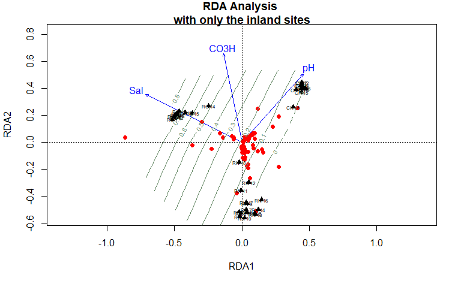

```r
ef <- with(
  varam[-c(1:3, 16:18, 34:38),],
  ordisurf(
    species.inland.vs,
    Sal,
    col = "darkseagreen4",
    display = "lc",
    nlevels = 10,
    add = TRUE)
  )
```

## Partial RDA - Inland Data

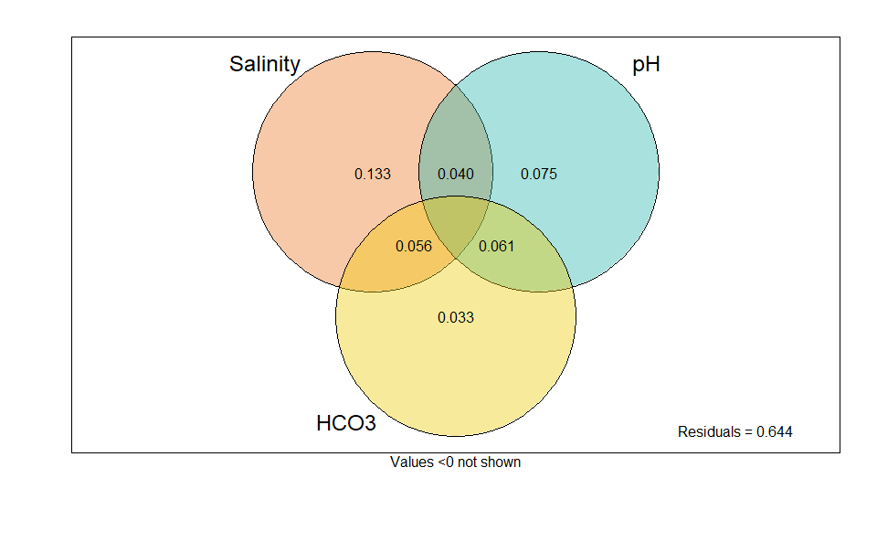

```r
RDA.part2 <- varpart(
  species.inland,
  ~ Sal,
  ~ pH,
  ~ CO3H,
  data = chem.inland,
  chisquare = T
  )

plot(
  RDA.part2,
  digits = 2,
  bg = c("chocolate2", "lightseagreen", "gold2"),
  alpha = 100,
  id.size = 1.5,
  Xnames = c("Salinity", "pH", "HCO3")
  )
```

# **Species Response Model (GLM)**

Determination of species response along the fluvials gradient based on Generalized Linear Model (GLM).

## Estuarine Species

```r
speciesRC.red1 <- speciesRC.red
speciesRN.red1 <- speciesRN.red
speciesCH.red1 <- speciesCH.red

colnames(speciesRC.red1) <- names[[1]][, 2]
colnames(speciesRN.red1) <- names[[2]][, 2]
colnames(speciesCH.red1) <- names[[3]][, 2]

species.rivers <- Merge(
  speciesRC.red1,
  speciesRN.red1,
  speciesCH.red1
)

SRM.estuaries <- cbind(species.rivers, varam$Sal)
names(SRM.estuaries)[92] <- "Salinity"

p4 <- ggplot(
  SRM.estuaries,
  aes(Salinity, AMAF/100)
  ) +
  geom_point(
    shape = 18,
    size = 3,
    color = "blue"
    ) +
  geom_smooth(
    method = "glm",
    method.args = list(family = "quasibinomial"),
    linetype = "dashed",
    color = "darkred",
    fill = "lightskyblue3"
    )+
  labs(
    x = "Salinity (‰)",
    y = "Relative Abundace",
    title = "Amphora affinis"
  ) +
  theme_minimal()

p5 <- ggplot(
  SRM.estuaries,
  aes(Salinity, CYBE/100)
  ) +
  geom_point(
    shape = 18,
    size = 3,
    color = "blue"
    ) +
  geom_smooth(
    method = "glm",
    method.args = list(family = "quasibinomial"),
    linetype = "dashed",
    color = "darkred",
    fill = "lightskyblue3"
    )+
  labs(
    x = "Salinity (‰)",
    y = "Relative Abundace",
    title = "Cymatosira belgica"
  ) +
  theme_minimal()

p6 <- ggplot(
  SRM.estuaries,
  aes(Salinity, DEMI/100)
  ) +
  geom_point(
    shape = 18,
    size = 3,
    color = "blue"
    ) +
  geom_smooth(
    method = "glm",
    method.args = list(family = "quasibinomial"),
    linetype = "dashed",
    color = "darkred",
    fill = "lightskyblue3"
    )+
  labs(
    x = "Salinity (‰)",
    y = "Relative Abundace",
    title = "Delphineis minutissima"
  ) +
  theme_minimal()

p7 <- ggplot(
  SRM.estuaries,
  aes(Salinity, DESU/100)
  ) +
  geom_point(
    shape = 18,
    size = 3,
    color = "blue"
    ) +
  geom_smooth(
    method = "glm",
    method.args = list(family = "quasibinomial"),
    linetype = "dashed",
    color = "darkred",
    fill = "lightskyblue3"
    )+
  labs(
    x = "Salinity (‰)",
    y = "Relative Abundace",
    title = "Delphineis surirella"
  ) +
  theme_minimal()

p8 <- ggplot(
  SRM.estuaries,
  aes(Salinity, OPMU/100)
  ) +
  geom_point(
    shape = 18,
    size = 3,
    color = "blue"
    ) +
  geom_smooth(
    method = "glm",
    method.args = list(family = "quasibinomial"),
    linetype = "dashed",
    color = "darkred",
    fill = "lightskyblue3"
    )+
  labs(
    x = "Salinity (‰)",
    y = "Relative Abundace",
    title = "Opephora mutabilis"
  ) +
  theme_minimal()

p9 <- ggplot(
  SRM.estuaries,
  aes(Salinity, PASU/100)
  ) +
  geom_point(
    shape = 18,
    size = 3,
    color = "blue"
    ) +
  geom_smooth(
    method = "glm",
    method.args = list(family = "quasibinomial"),
    linetype = "dashed",
    color = "darkred",
    fill = "lightskyblue3"
    )+
  labs(
    x = "Salinity (‰)",
    y = "Relative Abundace",
    title = "Paralia sulcata"
  ) +
  theme_minimal()

p10 <- ggplot(
  SRM.estuaries,
  aes(Salinity, PACO/100)
  ) +
  geom_point(
    shape = 18,
    size = 3,
    color = "blue"
    ) +
  geom_smooth(
    method = "glm",
    method.args = list(family = "quasibinomial"),
    linetype = "dashed",
    color = "darkred",
    fill = "lightskyblue3"
    )+
  labs(
    x = "Salinity (‰)",
    y = "Relative Abundace",
    title = "P. sulcata var. coronata"
  ) +
  theme_minimal()

p11 <- ggplot(
  SRM.estuaries,
  aes(Salinity, RHAM/100)
  ) +
  geom_point(
    shape = 18,
    size = 3,
    color = "blue"
    ) +
  geom_smooth(
    method = "glm",
    method.args = list(family = "quasibinomial"),
    linetype = "dashed",
    color = "darkred",
    fill = "lightskyblue3"
    )+
  labs(
    x = "Salinity (‰)",
    y = "Relative Abundace",
    title = "Rhaphoneis amphiceros"
  ) +
  theme_minimal()
```

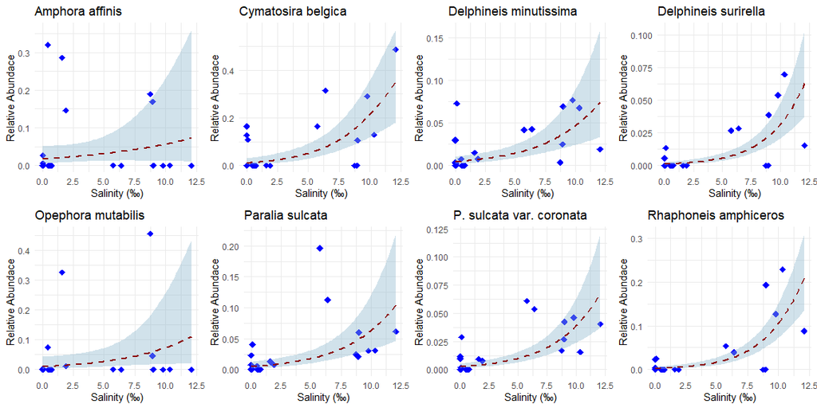

```r
grid.arrange(p4, p5, p6, p7, p8, p9, p10, p11, nrow =2, ncol = 4)
```

## Inland Species

```r
SRM.inland <- cbind(species.rivers, varam$Cond*1000)
names(SRM.inland)[92] <- "Conductivity"

p12 <- ggplot(
  SRM.inland,
  aes(Conductivity, STVE/100)
  ) +
  geom_point(
    shape = 18,
    size = 3,
    color = "blue"
    ) +
  geom_smooth(
    method = "glm",
    method.args = list(family = "quasibinomial"),
    linetype = "dashed",
    color = "darkred",
    fill = "lightskyblue3"
    )+
  labs(
    x = "Conductivity",
    y = "Relative Abundace",
    title = "Staurosira venter"
  ) +
  theme_minimal()

p13 <- ggplot(
  SRM.inland,
  aes(Conductivity, PUGL/100)
  ) +
  geom_point(
    shape = 18,
    size = 3,
    color = "blue"
    ) +
  geom_smooth(
    method = "glm",
    method.args = list(family = "quasibinomial"),
    linetype = "dashed",
    color = "darkred",
    fill = "lightskyblue3"
    )+
  labs(
    x = "Conductivity",
    y = "Relative Abundace",
    title = "Punctastriata glubokoensis"
  ) +
  theme_minimal()

p14 <- ggplot(
  SRM.inland,
  aes(Conductivity, PULA/100)
  ) +
  geom_point(
    shape = 18,
    size = 3,
    color = "blue"
    ) +
  geom_smooth(
    method = "glm",
    method.args = list(family = "quasibinomial"),
    linetype = "dashed",
    color = "darkred",
    fill = "lightskyblue3"
    )+
  labs(
    x = "Conductivity",
    y = "Relative Abundace",
    title = "Punctastriata glubokoensis"
  ) +
  theme_minimal()

p15 <- ggplot(
  SRM.inland,
  aes(Conductivity, EPSO/100)
  ) +
  geom_point(
    shape = 18,
    size = 3,
    color = "blue"
    ) +
  geom_smooth(
    method = "glm",
    method.args = list(family = "quasibinomial"),
    linetype = "dashed",
    color = "darkred",
    fill = "lightskyblue3"
    )+
  labs(
    x = "Conductivity",
    y = "Relative Abundace",
    title = "Epithemia sorex"
  ) +
  theme_minimal()

p16 <- ggplot(
  SRM.inland,
  aes(Conductivity, PSBR/100)
  ) +
  geom_point(
    shape = 18,
    size = 3,
    color = "blue"
    ) +
  geom_smooth(
    method = "glm",
    method.args = list(family = "quasibinomial"),
    linetype = "dashed",
    color = "darkred",
    fill = "lightskyblue3"
    )+
  labs(
    x = "Conductivity",
    y = "Relative Abundace",
    title = "Pseudostaurosira brevistriata"
  ) +
  theme_minimal()

p17 <- ggplot(
  SRM.inland,
  aes(Conductivity, STCO/100)
  ) +
  geom_point(
    shape = 18,
    size = 3,
    color = "blue"
    ) +
  geom_smooth(
    method = "glm",
    method.args = list(family = "quasibinomial"),
    linetype = "dashed",
    color = "darkred",
    fill = "lightskyblue3"
    )+
  labs(
    x = "Conductivity",
    y = "Relative Abundace",
    title = "Staurosira construens"
  ) +
  theme_minimal()

p18 <- ggplot(
  SRM.inland,
  aes(Conductivity, STBI/100)
  ) +
  geom_point(
    shape = 18,
    size = 3,
    color = "blue"
    ) +
  geom_smooth(
    method = "glm",
    method.args = list(family = "quasibinomial"),
    linetype = "dashed",
    color = "darkred",
    fill = "lightskyblue3"
    )+
  labs(
    x = "Conductivity",
    y = "Relative Abundace",
    title = "Staurosira binodis"
  ) +
  theme_minimal()

p19 <- ggplot(
  SRM.inland,
  aes(Conductivity, CYOC/100)
  ) +
  geom_point(
    shape = 18,
    size = 3,
    color = "blue"
    ) +
  geom_smooth(
    method = "glm",
    method.args = list(family = "quasibinomial"),
    linetype = "dashed",
    color = "darkred",
    fill = "lightskyblue3"
    )+
  labs(
    x = "Conductivity",
    y = "Relative Abundace",
    title = "Cyclotella ocellata"
  ) +
  theme_minimal()

p20 <- ggplot(
  SRM.inland,
  aes(Conductivity, COPL/100)
  ) +
  geom_point(
    shape = 18,
    size = 3,
    color = "blue"
    ) +
  geom_smooth(
    method = "glm",
    method.args = list(family = "quasibinomial"),
    linetype = "dashed",
    color = "darkred",
    fill = "lightskyblue3"
    )+
  labs(
    x = "Conductivity",
    y = "Relative Abundace",
    title = "Cocconeis placentula"
  ) +
  theme_minimal()

p21 <- ggplot(
  SRM.inland,
  aes(Conductivity, COPE/100)
  ) +
  geom_point(
    shape = 18,
    size = 3,
    color = "blue"
    ) +
  geom_smooth(
    method = "glm",
    method.args = list(family = "quasibinomial"),
    linetype = "dashed",
    color = "darkred",
    fill = "lightskyblue3"
    )+
  labs(
    x = "Conductivity",
    y = "Relative Abundace",
    title = "Cocconeis pediculus"
  ) +
  theme_minimal()

p22 <- ggplot(
  SRM.inland,
  aes(Conductivity, COEU/100)
  ) +
  geom_point(
    shape = 18,
    size = 3,
    color = "blue"
    ) +
  geom_smooth(
    method = "glm",
    method.args = list(family = "quasibinomial"),
    linetype = "dashed",
    color = "darkred",
    fill = "lightskyblue3"
    )+
  labs(
    x = "Conductivity",
    y = "Relative Abundace",
    title = "Cocconeis euglypta"
  ) +
  theme_minimal()

p23 <- ggplot(
  SRM.inland,
  aes(Conductivity, SAGA/100)
  ) +
  geom_point(
    shape = 18,
    size = 3,
    color = "blue"
    ) +
  geom_smooth(
    method = "glm",
    method.args = list(family = "quasibinomial"),
    linetype = "dashed",
    color = "darkred",
    fill = "lightskyblue3"
    )+
  labs(
    x = "Conductivity",
    y = "Relative Abundace",
    title = "Stephanodiscus agassizensis"
  ) +
  theme(legend.title = "GLM fit") +
  theme_minimal()
```

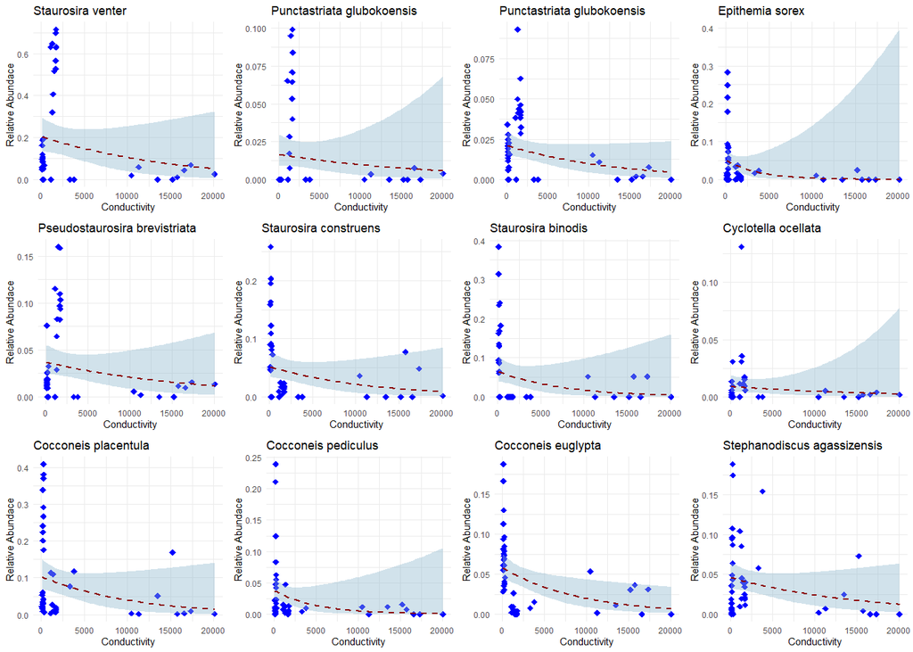

```r
grid.arrange(p12, p13, p14, p15, p16, p17, p18, p19, p20, p21, p22, p23, nrow =3, ncol = 4)
```